# Simple Linear Regression with Punta Cana Airbnb Data

04-12-2026

## Introduction: Rationale for Completing This Analysis

Given the recent volatility in the stock market, I have decided to diversify my long‑term investment strategy by opening a self‑directed Roth IRA to purchase real estate in Punta Cana, Dominican Republic. My goal is to acquire a property that can operate as a profitable Airbnb rental while also appreciating in value over time.

To make informed investment decisions, I need to understand which property features — such as the number of bedrooms — make a listing more attractive to tourists and more lucrative as a short‑term rental. This analysis uses real Punta Cana listing data to explore how bedroom count relates to nightly rental rates, forming the foundation for more advanced modeling project.

## Data Overview

```
##     bedrooms      ttm_avg_rate
##  Min.   :1.000   Min.   :  18.30
##  1st Qu.:1.000   1st Qu.:  63.20
##  Median :2.000   Median :  99.25
##  Mean   :2.147   Mean   : 177.45
##  3rd Qu.:3.000   3rd Qu.: 164.88
##  Max.   :7.000   Max.   :2738.10
```

## Scatterplot: Bedrooms vs Nightly Rate

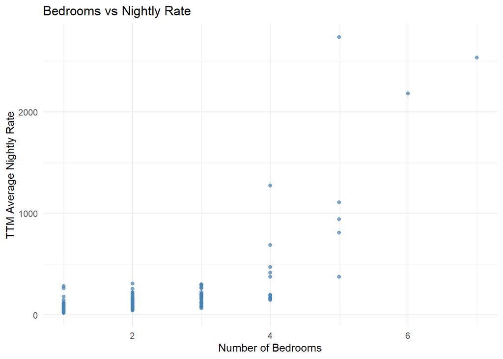

This scatterplot shows that listings with more bedrooms tend to command higher prices.

## Scatterplot with Regression Line

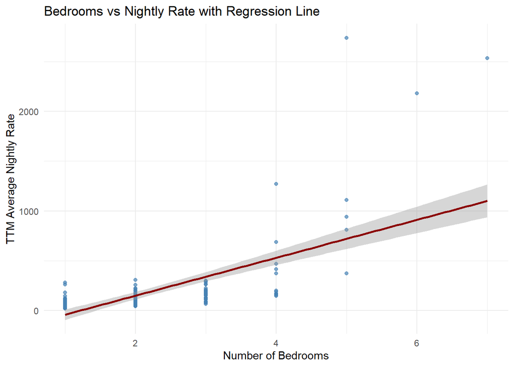

The regression line shows nightly rates increase as bedroom count rises.

## Regression Model Output

```
##
## Call:
## lm(formula = ttm_avg_rate ~ bedrooms, data = pdc_small)
##
## Residuals:
##     Min      1Q  Median      3Q     Max
## -384.74 -102.09  -41.81   98.40 2017.90
##
## Coefficients:
##             Estimate Std. Error t value Pr(>|t|)
## (Intercept)  -231.11      40.50  -5.707 4.41e-08 ***
## bedrooms      190.26      16.72  11.377  < 2e-16 ***
## ---
## Signif. codes:  0 '***' 0.001 '**' 0.01 '*' 0.05 '.' 0.1 ' ' 1
##
## Residual standard error: 257.9 on 188 degrees of freedom
## Multiple R-squared:  0.4077, Adjusted R-squared:  0.4046
## F-statistic: 129.4 on 1 and 188 DF,  p-value: < 2.2e-16
```

## Regression Equation

Using the coefficient estimates from the regression output: - Intercept (β0) = -231.11 - Slope (β1) = 190.26

## The fitted regression equation is:

\[ \hat{Y} = -231.11 + 190.26 \cdot \text{Bedrooms} \]

## Standard Error of the Regression

The **standard error of the regression (SER)** measures the typical size of the residuals — how far the observed nightly rates deviate from the regression line.

\[ SER = \sqrt{\frac{1}{n - 2} \sum_{i=1}^{n} (y_i - \hat{y}_i)^2} \]

## Interpretation of the Slope

The estimated slope for **bedrooms** is **190.26**.  
This means:

**For every additional bedroom, the predicted TTM average nightly rate increases by about $190.26 on average.**

Because the p‑value for the slope is extremely small (\(< 2e-16\)), the relationship between bedrooms and nightly rate is **statistically significant**.

## Interpretation of the Intercept

The intercept is **–231.11**, which represents the predicted nightly rate when the number of bedrooms is zero.

This value is **not meaningful in a real‑estate context**, but it is required mathematically to anchor the regression line.

## Interpretation of R-Squared

The regression model has an R-squared value of **0.4077**.

This means:

**Approximately 40.8% of the variation in TTM average nightly rate is explained by differences in the number of bedrooms.**

This indicates a moderately strong relationship for a single‑predictor model.

## Interpretation of Overall Model Significance

The F-statistic is **129.4** with a p-value **< 2.2e-16**.

This indicates:

**The overall regression model is statistically significant**, meaning bedrooms meaningfully predict nightly rate.

## Conclusion

Based on this simple linear regression analysis:

- The number of bedrooms is a **statistically significant** predictor of TTM average nightly rate.
- Each additional bedroom is associated with an estimated **$190.26 increase** in nightly rate, on average.
- The model explains approximately **40.8%** of the variation in nightly rates.
- While bedrooms matter, other variables not included in this simple model also influence pricing.

Overall, there is a clear positive relationship between bedroom count and nightly rate, and this model provides a strong first step in understanding pricing dynamics in this market.

Next Steps are to perform a multiple regression analysis to identify all the key metrics which influence pricing for Airbnb’s in Punta Cana.

## Why Include Diagnostic Plots?

To ensure that the simple linear regression model is appropriate for this analysis, it is important to evaluate whether the model assumptions are reasonably met.

- **Residual Plot** — checks whether the relationship is approximately linear and whether the residuals show constant variance across fitted values.
- **Fitted vs Actual Plot** — visualizes how well the model’s predictions align with the true nightly rates.
- **Purpose** — these diagnostics help confirm that the model is reliable and that the conclusions drawn from it are valid.

Including these plots strengthens the credibility of the analysis and provides a more complete understanding of model performance.

## Residual Plot

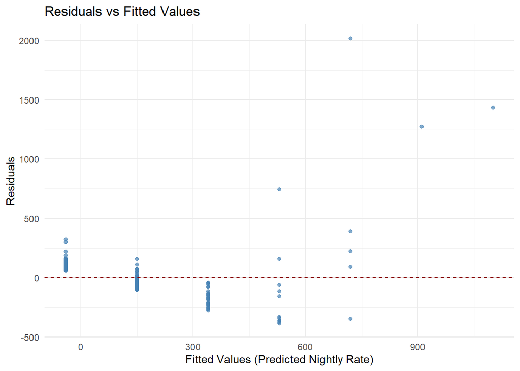

## Fitted vs Actual Plot

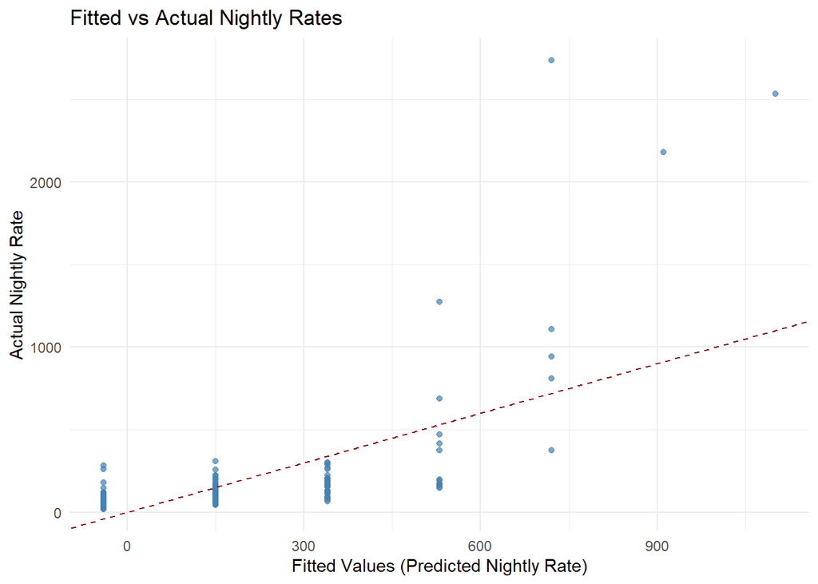

Points that fall close to the dashed 45‑degree line indicate accurate predictions.

## Interactive Plotly Scatterplot

[interactive chart not shown]

## Thank You

Questions or comments are welcome.